# Titanic_Final

Aditya Kaul

July 31, 2016

# Variable Descriptions:

- survival - Survival (0 = No; 1 = Yes)
- pclass - Passenger Class (1 = 1st; 2 = 2nd; 3 = 3rd)
- name - Name
- sex - Sex
- age - Age
- sibsp - Number of Siblings/Spouses Aboard
- parch - Number of Parents/Children Aboard
- ticket - Ticket Number
- fare - Passenger Fare
- cabin - Cabin
- embarked - Port of Embarkation (C = Cherbourg; Q = Queenstown; S = Southampton)

# Special Notes:

- Pclass is a proxy for socio-economic status (SES) (1st ~ Upper; 2nd ~ Middle; 3rd ~ Lower)
- Age is in Years; Fractional if Age less than One (1). If the Age is Estimated, it is in the form xx.5
- With respect to the family relation variables (i.e. sibsp and parch) some relations were ignored. The following are the definitions used for sibsp and parch.
- Sibling: Brother, Sister, Stepbrother, or Stepsister of Passenger Aboard Titanic
- Spouse: Husband or Wife of Passenger Aboard Titanic (Mistresses and Fiances Ignored)
- Parent: Mother or Father of Passenger Aboard Titanic
- Child: Son, Daughter, Stepson, or Stepdaughter of Passenger Aboard Titanic
- Other family relatives excluded from this study include cousins, nephews/nieces, aunts/uncles, and in-laws. Some children travelled only with a nanny, therefore parch=0 for them. As well, some travelled with very close friends or neighbors in a village, however, the definitions do not support such relations.

```r
#Install and load all necessary libraries
library('corrplot')
library('MASS')
library('tree')
library('randomForest')
library('gbm')
library('ggplot2')
library('wordcloud')
library('party')
library('rpart')
library('rattle')
library('rpart.plot')
library('RColorBrewer')
```

##### We need to set the seed before we start with our analysis since we are splitting the data set randomly. In order to ensure that the outcome of our models remains constant with our explanation we have a seed. We follow this by storing the training data set into a local variable and use the str() function to look at the data types and initial content of each variable in the data frame.

```
## 'data.frame':    891 obs. of  12 variables:
##  $ PassengerId: int  1 2 3 4 5 6 7 8 9 10 ...
##  $ Survived   : int  0 1 1 1 0 0 0 0 1 1 ...
##  $ Pclass     : int  3 1 3 1 3 3 1 3 3 2 ...
##  $ Name       : Factor w/ 891 levels "Abbing, Mr. Anthony",..: 109 191 358 277 16 559 520 629 417 581 ...
##  $ Sex        : Factor w/ 2 levels "female","male": 2 1 1 1 2 2 2 2 1 1 ...
##  $ Age        : num  22 38 26 35 35 NA 54 2 27 14 ...
##  $ SibSp      : int  1 1 0 1 0 0 0 3 0 1 ...
##  $ Parch      : int  0 0 0 0 0 0 0 1 2 0 ...
##  $ Ticket     : Factor w/ 681 levels "110152","110413",..: 524 597 670 50 473 276 86 396 345 133 ...
##  $ Fare       : num  7.25 71.28 7.92 53.1 8.05 ...
##  $ Cabin      : Factor w/ 148 levels "","A10","A14",..: 1 83 1 57 1 1 131 1 1 1 ...
##  $ Embarked   : Factor w/ 4 levels "","C","Q","S": 4 2 4 4 4 3 4 4 4 2 ...
```

##### Since variables such as name, ticket and cabin should ideally be strings rather than factors we perform the required type conversion and use the str() function to view the variables again.

```r
#Names, Tickets, Cabin are strings and not factors
training_titanic$Name <- as.character(training_titanic$Name)
training_titanic$Ticket <- as.character(training_titanic$Ticket)
training_titanic$Cabin <- as.character(training_titanic$Cabin)

#Check to see if the changes are successful
str(training_titanic)
```

```
## 'data.frame':    891 obs. of  12 variables:
##  $ PassengerId: int  1 2 3 4 5 6 7 8 9 10 ...
##  $ Survived   : int  0 1 1 1 0 0 0 0 1 1 ...
##  $ Pclass     : int  3 1 3 1 3 3 1 3 3 2 ...
##  $ Name       : chr  "Braund, Mr. Owen Harris" "Cumings, Mrs. John Bradley (Florence Briggs Thayer)" "Heikkinen, Miss. Laina" "Futrelle, Mrs. Jacques Heath (Lily May Peel)" ...
##  $ Sex        : Factor w/ 2 levels "female","male": 2 1 1 1 2 2 2 2 1 1 ...
##  $ Age        : num  22 38 26 35 35 NA 54 2 27 14 ...
##  $ SibSp      : int  1 1 0 1 0 0 0 3 0 1 ...
##  $ Parch      : int  0 0 0 0 0 0 0 1 2 0 ...
##  $ Ticket     : chr  "A/5 21171" "PC 17599" "STON/O2. 3101282" "113803" ...
##  $ Fare       : num  7.25 71.28 7.92 53.1 8.05 ...
##  $ Cabin      : chr  "" "C85" "" "C123" ...
##  $ Embarked   : Factor w/ 4 levels "","C","Q","S": 4 2 4 4 4 3 4 4 4 2 ...
```

# Feature Generation

##### We know that some of the variables do not provide insight directly and hence we perform feature generation which involves creation of new features from existing features. Here we split the name the get the title of the passenger.

```r
#Split the Name
strsplit(training_titanic$Name[2]," ")
```

```
## [[1]]
## [1] "Cumings,"  "Mrs."      "John"      "Bradley"   "(Florence" "Briggs"
## [7] "Thayer)"
```

```r
#Last Name
x <- strsplit(training_titanic$Name[2]," ")[[1]][1]
#Remove the comma from the string
gsub(",",x,replacement = "")
```

```
## [1] "Cumings"
```

```r
#Title of the passenger
y <- strsplit(training_titanic$Name[2]," ")[[1]][2]
```

##### Split the names of the passengers to get the titles of the passengers as well as the last name. We use the titles to differentiate the boys, girls, men, women and the special passengers on baord the Titanic. The last name helps us find the families since the last name would be the same for family members.

```r
#The above split results in some names getting split into the Title domain
#Hence we perform the split in the following way instead involving automation of the process
l <- strsplit(training_titanic$Name,",")
length(l)
```

```
## [1] 891
```

```r
x <- c()
p <- c()
for(i in 1:length(l)){
  x[i] <- strsplit(training_titanic$Name,",")[[i]][1]
  p[i] <- strsplit(training_titanic$Name,",")[[i]][2]
}
head(x)
```

```
## [1] "Braund"    "Cumings"   "Heikkinen" "Futrelle"  "Allen"     "Moran"
```

```r
head(p)
```

```
## [1] " Mr. Owen Harris"
## [2] " Mrs. John Bradley (Florence Briggs Thayer)"
## [3] " Miss. Laina"
## [4] " Mrs. Jacques Heath (Lily May Peel)"
## [5] " Mr. William Henry"
## [6] " Mr. James"
```

```r
n <- strsplit(p," ")
length(n)
```

```
## [1] 891
```

```r
head(n)
```

```
## [[1]]
## [1] ""       "Mr."    "Owen"   "Harris"
##
## [[2]]
## [1] ""          "Mrs."      "John"      "Bradley"   "(Florence" "Briggs"
## [7] "Thayer)"
##
## [[3]]
## [1] ""      "Miss." "Laina"
##
## [[4]]
## [1] ""        "Mrs."    "Jacques" "Heath"   "(Lily"   "May"     "Peel)"
##
## [[5]]
## [1] ""        "Mr."     "William" "Henry"
##
## [[6]]
## [1] ""      "Mr."   "James"
```

```r
for(i in 1:length(n)){
  y[i] <- n[[i]][2]
  #y[i] <- gsub(",",x[i],replacement = "")
  #p[i] <- gsub("")
}
head(y)
```

```
## [1] "Mr."   "Mrs."  "Miss." "Mrs."  "Mr."   "Mr."
```

```r
unique(y)
```

```
##  [1] "Mr."       "Mrs."      "Miss."     "Master."   "Don."
##  [6] "Rev."      "Dr."       "Mme."      "Ms."       "Major."
## [11] "Lady."     "Sir."      "Mlle."     "Col."      "Capt."
## [16] "the"       "Jonkheer."
```

##### Create new columns in the data frame for Last Name and Title

```r
training_titanic$LastName <- x
training_titanic$Title <- y
```

##### Mme. is the French term for Mrs. Similarly, Mlle. is the French term for Miss. whereas Ms. is the English term for Miss.

```r
#We replace the unique desingations with "Special" but when we are imputing the age for those missing
#we consider not just the gender, but also the Title especially for master and miss
#It does not make sense to give children the average age of the older people included
training_titanic$Title[training_titanic$Title == "Mme."] <- "Mrs."
training_titanic$Title[training_titanic$Title == "Mlle." | training_titanic$Title == "Ms."] <- "Miss."
```

##### Find all the unique titles and for any title which is not Mr, Mrs, Master and Miss and rename them as special

```r
#Split the training data based on gender
unique(training_titanic$Title)
```

```
##  [1] "Mr."       "Mrs."      "Miss."     "Master."   "Don."
##  [6] "Rev."      "Dr."       "Major."    "Lady."     "Sir."
## [11] "Col."      "Capt."     "the"       "Jonkheer."
```

```r
training_male <- subset(training_titanic, training_titanic$Sex=="male" & (training_titanic$Title=="Mr." | training_titanic$Title=="Sir."| training_titanic$Title=="Col." | training_titanic$Title=="Capt."| training_titanic$Title=="Jonkheer."| training_titanic$Title=="Rev." | training_titanic$Title=="Dr." | training_titanic$Title=="Don." | training_titanic$Title=="Major."))
#unique(training_male$Title)
training_female <- subset(training_titanic, training_titanic$Sex=="female" & (training_titanic$Title=="Mrs." | training_titanic$Title == "Lady."| training_titanic$Title=="the"))
training_boy <- subset(training_titanic, training_titanic$Sex=="male" & training_titanic$Title=="Master.")
training_girl <- subset(training_titanic, training_titanic$Sex=="female" & training_titanic$Title=="Miss.")

#Compare to see if after our data transformations the number of observations match
nrow(training_titanic)
```

```
## [1] 891
```

```r
nrow(training_girl) + nrow(training_boy) + nrow(training_female) + nrow(training_male)
```

```
## [1] 890
```

```r
#training_titanic$Name[training_titanic$Title=="the"]
```

##### Impute the missing Age values by using the relevant ages from the subsets

```r
#Imputing the NULL and NA values with the mean age for the relevant subsets
training_male$Age[is.na(training_male$Age)] <-
  mean(training_titanic$Age[training_titanic$Sex=="male" & training_titanic$Title=="Mr."], na.rm = T)
training_female$Age[is.na(training_female$Age)] <-
  mean(training_titanic$Age[training_titanic$Sex=="female" & training_titanic$Title=="Mrs."], na.rm = T)
training_boy$Age[is.na(training_boy$Age)] <-
  mean(training_titanic$Age[training_titanic$Sex=="male" & training_titanic$Title=="Master."], na.rm = T)
training_girl$Age[is.na(training_girl$Age)] <-
  mean(training_titanic$Age[training_titanic$Sex=="female" & training_titanic$Title=="Miss."], na.rm = T)
```

##### Combine these subsets to create the training set. Add a new column to the training dataset called Fam which represents the number of family members that passenger has which is a combination of SibSp and Parch.

```r
#Combine the two subsets together to get the original training dataset
training <- rbind(training_male, training_female, training_boy, training_girl)

#Create another variable that combines the SibSp and Parch to give total family members
training$Fam <- training$SibSp + training$Parch
```

# Exploratory Analysis

##### As we can see from the first plot, survival rate is higher for people who paid a higher fare

```r
#Exploratory Analysis
max(training$Fare)
```

```
## [1] 512.3292
```

```r
min(training$Fare)
```

```
## [1] 0
```

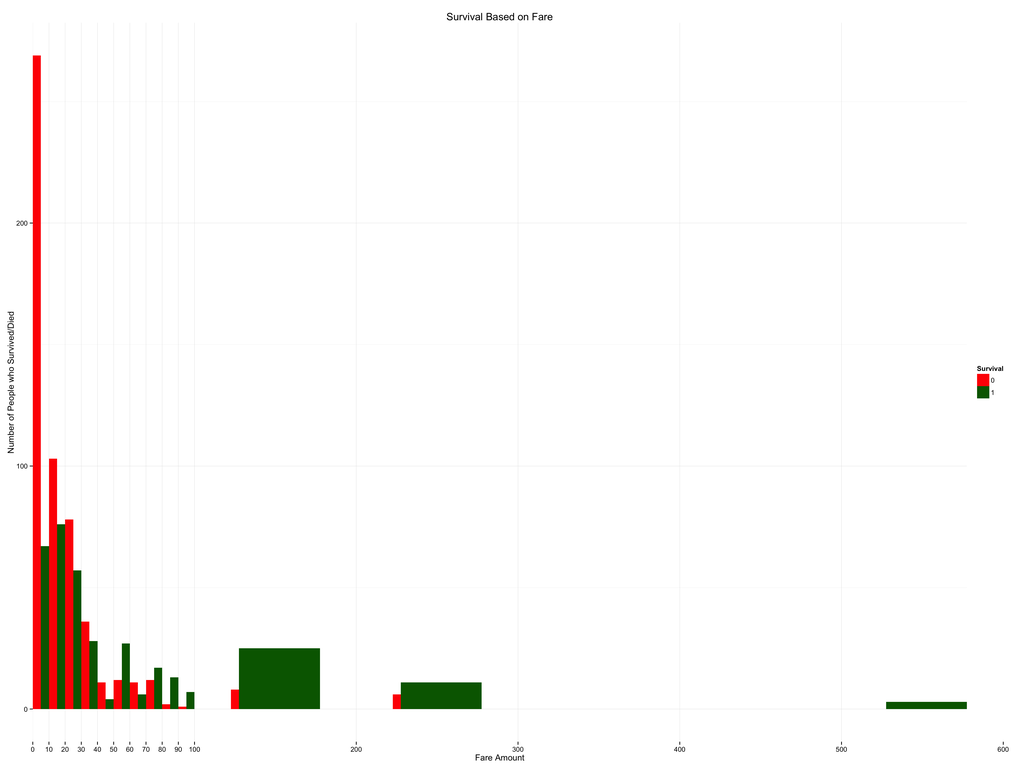

```r
legend_title <- "Survival"
ggplot(data = training, aes(x=Fare, fill=as.factor(Survived)))+
  geom_histogram(breaks = c(0,10,20,30,40,50,60,70,80,90,100,200,300,400,500,600), position = "dodge")+
  scale_fill_manual(legend_title,values=c("red","dark green"))+
  theme_minimal()+
  scale_x_discrete(limits = c(0,10,20,30,40,50,60,70,80,90,100,200,300,400,500,600))+
  ggtitle("Survival Based on Fare")+
  xlab("Fare Amount")+
  ylab("Number of People who Survived/Died")
```

##### Reuse the multiple plot function that enables us to plot more than one ggplot

```r
# Multiple plot function
#
# ggplot objects can be passed in ..., or to plotlist (as a list of ggplot objects)
# - cols:   Number of columns in layout
# - layout: A matrix specifying the layout. If present, 'cols' is ignored.
#
# If the layout is something like matrix(c(1,2,3,3), nrow=2, byrow=TRUE),
# then plot 1 will go in the upper left, 2 will go in the upper right, and
# 3 will go all the way across the bottom.
#
multiplot <- function(..., plotlist=NULL, file, cols=1, layout=NULL) {
  library(grid)

  # Make a list from the ... arguments and plotlist
  plots <- c(list(...), plotlist)

  numPlots = length(plots)

  # If layout is NULL, then use 'cols' to determine layout
  if (is.null(layout)) {
    # Make the panel
    # ncol: Number of columns of plots
    # nrow: Number of rows needed, calculated from # of cols
    layout <- matrix(seq(1, cols * ceiling(numPlots/cols)),
                     ncol = cols, nrow = ceiling(numPlots/cols))
  }

  if (numPlots==1) {
    print(plots[[1]])

  } else {
    # Set up the page
    grid.newpage()
    pushViewport(viewport(layout = grid.layout(nrow(layout), ncol(layout))))

    # Make each plot, in the correct location
    for (i in 1:numPlots) {
      # Get the i,j matrix positions of the regions that contain this subplot
      matchidx <- as.data.frame(which(layout == i, arr.ind = TRUE))

      print(plots[[i]], vp = viewport(layout.pos.row = matchidx$row,
                                      layout.pos.col = matchidx$col))
    }
  }
}
```

```r
legend_title <- "Survival"
Family <- ggplot(data = training, aes(x=as.factor(Fam), fill=as.factor(Survived)))+
  geom_bar(position = "dodge")+
  scale_fill_manual(legend_title,values=c("red","dark green"))+
  theme_minimal()+
  ggtitle("Survival Based on Number of Family Members")+
  xlab("Number of Family Members")+
  ylab("Number of People who Survived/Died")
```

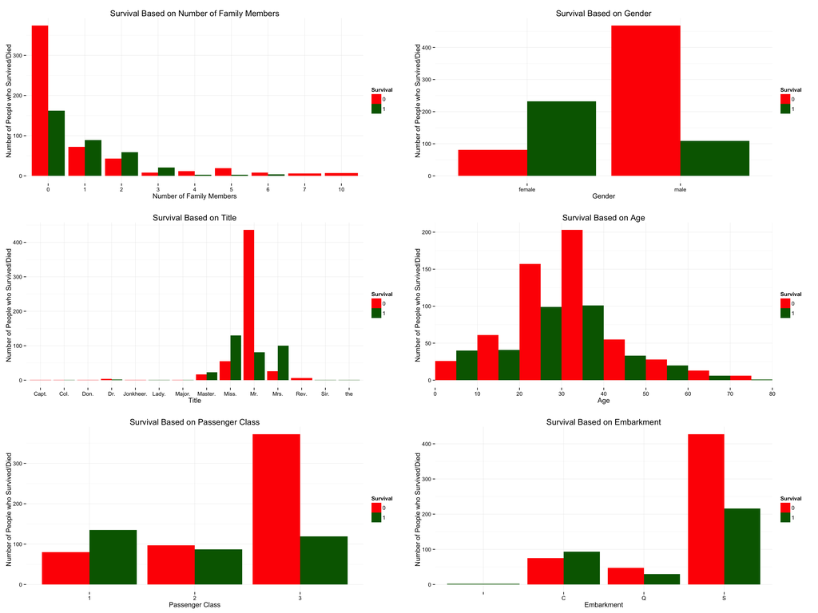

```r
legend_title <- "Survival"
Title <- ggplot(data = training, aes(x=as.factor(Title), fill=as.factor(Survived)))+
  geom_bar(position = "dodge")+
  scale_fill_manual(legend_title,values=c("red","dark green"))+
  theme_minimal()+
  ggtitle("Survival Based on Title")+
  xlab("Title")+
  ylab("Number of People who Survived/Died")



legend_title <- "Survival"
Class <- ggplot(data = training, aes(x=as.factor(Pclass), fill=as.factor(Survived)))+
  geom_bar(position = "dodge")+
  scale_fill_manual(legend_title,values=c("red","dark green"))+
  theme_minimal()+
  ggtitle("Survival Based on Passenger Class")+
  xlab("Passenger Class")+
  ylab("Number of People who Survived/Died")


legend_title <- "Survival"
Gender <- ggplot(data = training, aes(x=as.factor(Sex), fill=as.factor(Survived)))+
  geom_bar(position = "dodge")+
  scale_fill_manual(legend_title,values=c("red","dark green"))+
  theme_minimal()+
  ggtitle("Survival Based on Gender")+
  xlab("Gender")+
  ylab("Number of People who Survived/Died")


legend_title <- "Survival"
Age <- ggplot(data = training, aes(x=Age, fill=as.factor(Survived)))+
  geom_histogram(breaks = c(0,10,20,30,40,50,60,70,80), position = "dodge")+
  scale_fill_manual(legend_title,values=c("red","dark green"))+
  theme_minimal()+
  scale_x_discrete(limits = c(0,10,20,30,40,50,60,70,80))+
  ggtitle("Survival Based on Age")+
  xlab("Age")+
  ylab("Number of People who Survived/Died")


legend_title <- "Survival"
Embarked <- ggplot(data = training, aes(x=Embarked, fill=as.factor(Survived)))+
  geom_bar(position = "dodge")+
  scale_fill_manual(legend_title,values=c("red","dark green"))+
  theme_minimal()+
  ggtitle("Survival Based on Embarkment")+
  xlab("Embarkment")+
  ylab("Number of People who Survived/Died")

multiplot(Family, Title, Class, Gender, Age, Embarked, cols = 2)
```

##### Create different subsets based on embarkation points

```r
#We note here that there appears to be someone that does not have an embarkation point
subset(training,training$Embarked =="")
```

```
##     PassengerId Survived Pclass                                      Name
## 830         830        1      1 Stone, Mrs. George Nelson (Martha Evelyn)
## 62           62        1      1                       Icard, Miss. Amelie
##        Sex Age SibSp Parch Ticket Fare Cabin Embarked LastName Title Fam
## 830 female  62     0     0 113572   80   B28             Stone  Mrs.   0
## 62  female  38     0     0 113572   80   B28             Icard Miss.   0
```

```r
#In order to assign them to the correct Embarkation group we need to see what the embarkation
#point of the people was who belonged to first class and survived
emb_q <- subset(training,training$Embarked =="Q")
emb_c <- subset(training,training$Embarked =="C")
emb_s <- subset(training,training$Embarked =="S")
```

##### Plot the survival rate of the passengers segregated by class for each embarkation point

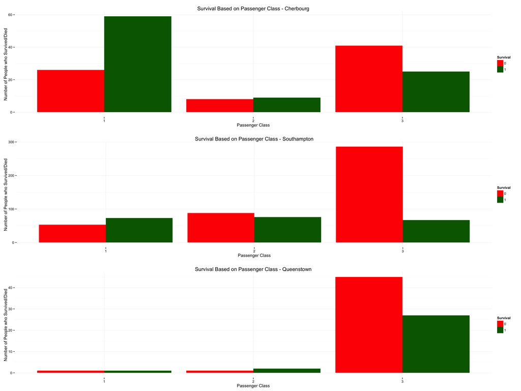

```r
plot_q <- ggplot(data = emb_q, aes(x=as.factor(Pclass), fill=as.factor(Survived)))+
  geom_bar(position = "dodge")+
  scale_fill_manual(legend_title,values=c("red","dark green"))+
  theme_minimal()+
  ggtitle("Survival Based on Passenger Class - Queenstown")+
  xlab("Passenger Class")+
  ylab("Number of People who Survived/Died")

plot_c <- ggplot(data = emb_c, aes(x=as.factor(Pclass), fill=as.factor(Survived)))+
  geom_bar(position = "dodge")+
  scale_fill_manual(legend_title,values=c("red","dark green"))+
  theme_minimal()+
  ggtitle("Survival Based on Passenger Class - Cherbourg")+
  xlab("Passenger Class")+
  ylab("Number of People who Survived/Died")

plot_s <- ggplot(data = emb_s, aes(x=as.factor(Pclass), fill=as.factor(Survived)))+
  geom_bar(position = "dodge")+
  scale_fill_manual(legend_title,values=c("red","dark green"))+
  theme_minimal()+
  ggtitle("Survival Based on Passenger Class - Southampton")+
  xlab("Passenger Class")+
  ylab("Number of People who Survived/Died")

multiplot(plot_c, plot_s, plot_q, cols = 1)
```

##### Assign the title “Special” to the high profile passengers on board

```r
unique(training$Title)
```

```
##  [1] "Mr."       "Don."      "Rev."      "Dr."       "Major."
##  [6] "Sir."      "Col."      "Capt."     "Jonkheer." "Mrs."
## [11] "Lady."     "the"       "Master."   "Miss."
```

```r
training$Title[training$Title == "Don." | training$Title == "Rev." | training$Title == "Dr." | training$Title == "Major." | training$Title == "Lady." | training$Title == "Sir." | training$Title == "Col." | training$Title == "Capt." | training$Title == "the" | training$Title == "Jonkheer."] <- "Special"

unique(training$Title)
```

```
## [1] "Mr."     "Special" "Mrs."    "Master." "Miss."
```

##### Create a wordcloud that shows the last names of people hence indicating the size of a family. The more the number of family memebers the larger the name on the wordcloud

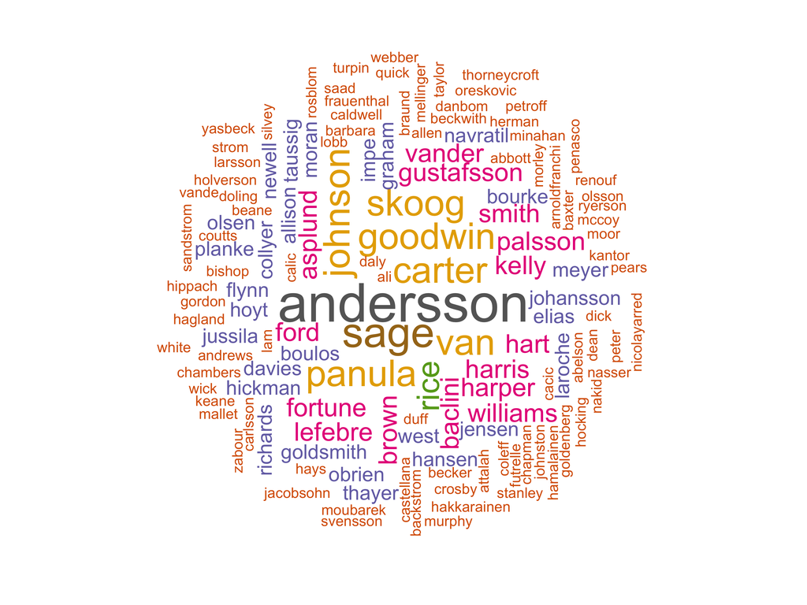

```r
#We plot members on board the Titanic with similar last names which might also indicate their family members
wordcloud(training$LastName,min.freq = 2, scale=c(8,0.5), max.words=2000, random.order=FALSE, rot.per=0.35, use.r.layout=FALSE, colors=brewer.pal(8, "Dark2"))
```

##### In order to perform the prediction we first shuffle the data that we have. We split the shuffled data into a training and validation set with a split 80-20

```r
#Split the training set into 80% training data and 20% validation data
#Shuffle the data
shuffled_training <- training[sample(nrow(training)),]
unique(shuffled_training$Title)
```

```
## [1] "Mrs."    "Mr."     "Special" "Miss."   "Master."
```

```r
#Find number of rows in the data set
#nrow(shuffled_training)

#Calculate 80% of the total number of observations
val <- floor(80*nrow(shuffled_training)/100)+1

#The final training set has 80% of our shuffled training set
final_training <- shuffled_training[1:floor(80*nrow(shuffled_training)/100),]
unique(final_training$Title)
```

```
## [1] "Mrs."    "Mr."     "Special" "Miss."   "Master."
```

```r
#We create a validation set that has 20% of the observations
final_validation <- shuffled_training[val:nrow(shuffled_training),]
unique(final_validation$Title)
```

```
## [1] "Mr."     "Mrs."    "Master." "Miss."   "Special"
```

##### Find the correlation between the different predictors by creating a correlation matrix. Also, plot the same to visually show the correlation

```r
cor_titanic <- cor(final_training[,c(2,3,7,8,10,15)])

#We find the correlation between the numeric predictors by plotting a correlation matrix
cor_titanic
```

```
##              Survived      Pclass       SibSp      Parch       Fare
## Survived  1.000000000 -0.32249244 -0.04022387 0.06075027  0.2712593
## Pclass   -0.322492437  1.00000000  0.08707291 0.03880500 -0.5482442
## SibSp    -0.040223868  0.08707291  1.00000000 0.38167448  0.1373638
## Parch     0.060750273  0.03880500  0.38167448 1.00000000  0.1845896
## Fare      0.271259253 -0.54824415  0.13736376 0.18458957  1.0000000
## Fam       0.004158804  0.07930965  0.87766271 0.77797732  0.1890891
##                  Fam
## Survived 0.004158804
## Pclass   0.079309652
## SibSp    0.877662712
## Parch    0.777977322
## Fare     0.189089114
## Fam      1.000000000
```

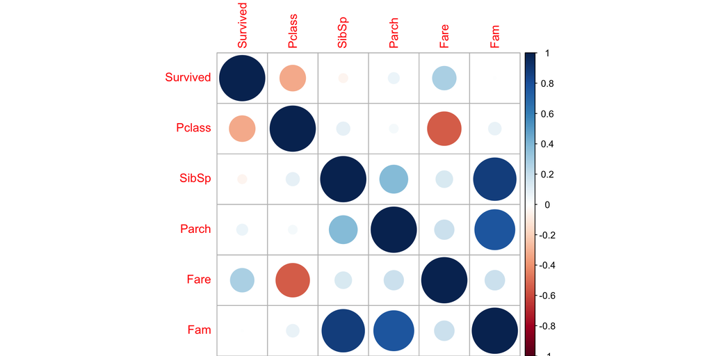

```r
#We also represent the same using a plot
corrplot(cor_titanic, method = "circle")
```

# Logistic Regression

##### We start with logistic regression with multiple predictors since we can see from the correlation matrix and the plot that there are multiple variables that seem to have a correlation with the response variable ‘Survived’. Also, starting with the most basic algorithm gives us an idea about the statistical significance of the predictors.

```r
#Create the model
glm_fit <- glm(Survived ~ Pclass +  Sex + Age + Fam + Title, data = final_training, family = binomial)

#Find the summary of the model
summary(glm_fit)
```

```
##
## Call:
## glm(formula = Survived ~ Pclass + Sex + Age + Fam + Title, family = binomial,
##     data = final_training)
##
## Deviance Residuals:
##     Min       1Q   Median       3Q      Max
## -2.3016  -0.5900  -0.4035   0.5290   2.6065
##
## Coefficients:
##               Estimate Std. Error z value Pr(>|z|)
## (Intercept)   20.86757  611.65949   0.034  0.97278
## Pclass        -1.17256    0.14175  -8.272  < 2e-16 ***
## Sexmale      -15.47371  611.65908  -0.025  0.97982
## Age           -0.03277    0.01029  -3.184  0.00145 **
## Fam           -0.45807    0.08730  -5.247 1.55e-07 ***
## TitleMiss.   -15.89752  611.65933  -0.026  0.97926
## TitleMr.      -3.26227    0.59249  -5.506 3.67e-08 ***
## TitleMrs.    -14.92626  611.65939  -0.024  0.98053
## TitleSpecial  -3.50456    0.85297  -4.109 3.98e-05 ***
## ---
## Signif. codes:  0 '***' 0.001 '**' 0.01 '*' 0.05 '.' 0.1 ' ' 1
##
## (Dispersion parameter for binomial family taken to be 1)
##
##     Null deviance: 948.92  on 711  degrees of freedom
## Residual deviance: 594.06  on 703  degrees of freedom
## AIC: 612.06
##
## Number of Fisher Scoring iterations: 13
```

##### Use the predict function to predict the values of the variable Survived in the validation set. Once we predict the value we want to play around with the threshold of our probability. In this case, any prediction over 0.6 gets assigned 1 which means that the person survived whereas any prediction below 0.6 gets assigned 0.

```r
#Predict whether the person survived or not by using the algorithm
final_validation$predicted <- predict(glm_fit, final_validation, type = "response")

#Assign 1 or 0 to the predictions that we made
final_validation$new[final_validation$predicted > 0.6] <- 1
final_validation$new[final_validation$predicted < 0.6] <- 0
```

##### Create a confusion matrix to find True Positive, True Negative, False Positive and False Negative. Also calculate the prediction accuracy of the classification

```r
#Create a confusion matrix
conf_tab <- table(final_validation$new, final_validation$Survived)
conf_tab
```

```
##
##       0   1
##   0 102  19
##   1   9  48
```

```r
#Calculate the misclassification error
misclassification <- (conf_tab[1,2] + conf_tab[2,1])/(conf_tab[1,1] + conf_tab[1,2] + conf_tab[2,1] + conf_tab[2,2])

paste0("Prediction accuracy is: ", round(100*(1-misclassification), 2), "%", sep="")
```

```
## [1] "Prediction accuracy is: 84.27%"
```

```r
#Create the model with the interaction terms
glm_fit_int <- glm(Survived ~ Pclass +  Sex + Age + Pclass*Sex + Fam + Title + Pclass*Fam + Pclass*Title + Age*Title, data = final_training, family = binomial)

#Find the summary of the model
summary(glm_fit_int)
```

```
##
## Call:
## glm(formula = Survived ~ Pclass + Sex + Age + Pclass * Sex +
##     Fam + Title + Pclass * Fam + Pclass * Title + Age * Title,
##     family = binomial, data = final_training)
##
## Deviance Residuals:
##     Min       1Q   Median       3Q      Max
## -3.6638  -0.5736  -0.4603   0.3749   2.5800
##
## Coefficients: (1 not defined because of singularities)
##                       Estimate Std. Error z value Pr(>|z|)
## (Intercept)          4.937e+01  2.109e+03   0.023   0.9813
## Pclass              -1.201e+00  5.249e-01  -2.287   0.0222 *
## Sexmale             -3.826e+00  1.809e+03  -0.002   0.9983
## Age                  3.967e-03  1.851e-01   0.021   0.9829
## Fam                  3.732e-01  3.547e-01   1.052   0.2927
## TitleMiss.          -4.035e+01  2.109e+03  -0.019   0.9847
## TitleMr.            -4.501e+01  1.879e+03  -0.024   0.9809
## TitleMrs.           -4.384e+01  2.109e+03  -0.021   0.9834
## TitleSpecial        -3.002e+01  2.061e+03  -0.015   0.9884
## Pclass:Sexmale      -1.328e+01  6.262e+02  -0.021   0.9831
## Pclass:Fam          -3.346e-01  1.347e-01  -2.484   0.0130 *
## Pclass:TitleMiss.   -1.067e+00  7.555e-01  -1.413   0.1577
## Pclass:TitleMr.      1.384e+01  6.262e+02   0.022   0.9824
## Pclass:TitleMrs.            NA         NA      NA       NA
## Pclass:TitleSpecial -1.450e+00  1.053e+03  -0.001   0.9989
## Age:TitleMiss.      -8.594e-02  1.865e-01  -0.461   0.6449
## Age:TitleMr.        -2.413e-02  1.856e-01  -0.130   0.8966
## Age:TitleMrs.       -2.123e-02  1.877e-01  -0.113   0.9100
## Age:TitleSpecial    -7.759e-03  1.936e-01  -0.040   0.9680
## ---
## Signif. codes:  0 '***' 0.001 '**' 0.01 '*' 0.05 '.' 0.1 ' ' 1
##
## (Dispersion parameter for binomial family taken to be 1)
##
##     Null deviance: 948.92  on 711  degrees of freedom
## Residual deviance: 565.11  on 694  degrees of freedom
## AIC: 601.11
##
## Number of Fisher Scoring iterations: 15
```

##### Use the predict function to predict the values of the variable Survived in the validation set. Once we predict the value we want to play around with the threshold of our probability. In this case, any prediction over 0.5 gets assigned 1 which means that the person survived whereas any prediction below 0.5 gets assigned 0.

```r
#Predict whether the person survived or not by using the algorithm
final_validation$predicted_int <- predict(glm_fit_int, final_validation, type = "response")

#Assign 1 or 0 to the predictions that we made
final_validation$new_int[final_validation$predicted_int > 0.5] <- 1
final_validation$new_int[final_validation$predicted_int < 0.5] <- 0
```

```r
#Create a confusion matrix
conf_tab_int <- table(final_validation$new_int, final_validation$Survived)
conf_tab_int
```

```
##
##       0   1
##   0 102  19
##   1   9  48
```

```r
#Calculate the misclassification error
misclassification_int <- (conf_tab_int[1,2] + conf_tab_int[2,1])/(conf_tab_int[1,1] + conf_tab_int[1,2] + conf_tab_int[2,1] + conf_tab_int[2,2])

paste0("Prediction accuracy is: ", round(100*(1-misclassification_int), 2), "%", sep="")
```

```
## [1] "Prediction accuracy is: 84.27%"
```

# Linear Discriminant Analysis

##### We know that LDA is another classification algorithm that is preferred to Logistic Regression when the response variable has more than two levels. However, since it is a classification algorithm let us see whether LDA does better than either of the two logistic Regression models that we had above.

```r
#Create the model
lda_fit <- lda(Survived ~ Pclass +  Sex + Age + Fam + Title, data = final_training)

#Find details about the model
lda_fit
```

```
## Call:
## lda(Survived ~ Pclass + Sex + Age + Fam + Title, data = final_training)
##
## Prior probabilities of groups:
##         0         1
## 0.6151685 0.3848315
##
## Group means:
##     Pclass   Sexmale      Age       Fam TitleMiss.  TitleMr.  TitleMrs.
## 0 2.509132 0.8470320 30.72566 0.9315068  0.1027397 0.7831050 0.05022831
## 1 1.952555 0.3211679 28.24425 0.9452555  0.3759124 0.2408759 0.29562044
##   TitleSpecial
## 0   0.03424658
## 1   0.02189781
##
## Coefficients of linear discriminants:
##                      LD1
## Pclass       -0.70940384
## Sexmale      -2.90301696
## Age          -0.01781006
## Fam          -0.25982471
## TitleMiss.   -2.99984891
## TitleMr.     -2.24869961
## TitleMrs.    -2.48270720
## TitleSpecial -2.51100867
```

##### Here we can see that there is not a lot of difference between the classification accuracy using Logistic regression and LDA. In fact since it is advisable to use Logistic regression when we have a binary response variable, we actually get a better classification accuracy using Logistic Regression as compared to LDA.

```r
#Predict whether the person survived or not by using the algorithm
lda_pred <- predict(lda_fit, final_validation)
#names(lda_pred)

#Create a confusion matrix
table(lda_pred$class, final_validation$Survived)
```

```
##
##      0  1
##   0 99 17
##   1 12 50
```

```r
#Calculate the classification accuracy
acc <- mean(lda_pred$class == final_validation$Survived)

paste0("Prediction accuracy is: ", round(100*(acc), 2), "%", sep="")
```

```
## [1] "Prediction accuracy is: 83.71%"
```

##### Here we perform LDA again but we also consider the interaction variables to see if there is an improved performance in classification

```r
#Perform the same LDA but by also considering interaction variables
lda_fit_int <- lda(Survived ~ Pclass +  Sex + Age + Fam + Pclass*Sex + Pclass*Fam + Title + Pclass*Title, data = final_training)

#Find details about the model
lda_fit_int
```

```
## Call:
## lda(Survived ~ Pclass + Sex + Age + Fam + Pclass * Sex + Pclass *
##     Fam + Title + Pclass * Title, data = final_training)
##
## Prior probabilities of groups:
##         0         1
## 0.6151685 0.3848315
##
## Group means:
##     Pclass   Sexmale      Age       Fam TitleMiss.  TitleMr.  TitleMrs.
## 0 2.509132 0.8470320 30.72566 0.9315068  0.1027397 0.7831050 0.05022831
## 1 1.952555 0.3211679 28.24425 0.9452555  0.3759124 0.2408759 0.29562044
##   TitleSpecial Pclass:Sexmale Pclass:Fam Pclass:TitleMiss. Pclass:TitleMr.
## 0   0.03424658      2.0730594   2.525114         0.2968037       1.9315068
## 1   0.02189781      0.6532847   1.828467         0.7591241       0.4854015
##   Pclass:TitleMrs. Pclass:TitleSpecial
## 0        0.1392694          0.05251142
## 1        0.5328467          0.02189781
##
## Coefficients of linear discriminants:
##                             LD1
## Pclass              -0.45630737
## Sexmale             -1.97106575
## Age                 -0.01573808
## Fam                  0.16033225
## TitleMiss.          -2.45677679
## TitleMr.            -3.83658089
## TitleMrs.           -2.54460328
## TitleSpecial        -2.26031043
## Pclass:Sexmale      -0.55534623
## Pclass:Fam          -0.14640806
## Pclass:TitleMiss.   -0.45114514
## Pclass:TitleMr.      0.62243515
## Pclass:TitleMrs.    -0.22924379
## Pclass:TitleSpecial -0.52466893
```

```r
#Predict whether the person survived or not by using the algorithm
lda_pred_int <- predict(lda_fit_int, final_validation)
#names(lda_pred_int)

#Create the confusion matrix
table(lda_pred_int$class, final_validation$Survived)
```

```
##
##       0   1
##   0 100  19
##   1  11  48
```

```r
#Calculate the classification accuracy
acc_int <- mean(lda_pred_int$class == final_validation$Survived)

paste0("Prediction accuracy is: ", round(100*(acc_int), 2), "%", sep="")
```

```
## [1] "Prediction accuracy is: 83.15%"
```

# Classification Tree

```r
#Create the model
class_tree <- tree(as.factor(Survived) ~ Pclass +  Sex + Age + Fam + Title, data = final_training)

#Find the summary of the model
summary(class_tree)
```

```
##
## Classification tree:
## tree(formula = as.factor(Survived) ~ Pclass + Sex + Age + Fam +
##     Title, data = final_training)
## Variables actually used in tree construction:
## [1] "Sex"    "Pclass" "Fam"    "Age"
## Number of terminal nodes:  7
## Residual mean deviance:  0.815 = 574.6 / 705
## Misclassification error rate: 0.1713 = 122 / 712
```

##### Plot the classification tree with the different nodes indicated by the predictors mentioned in the tree model

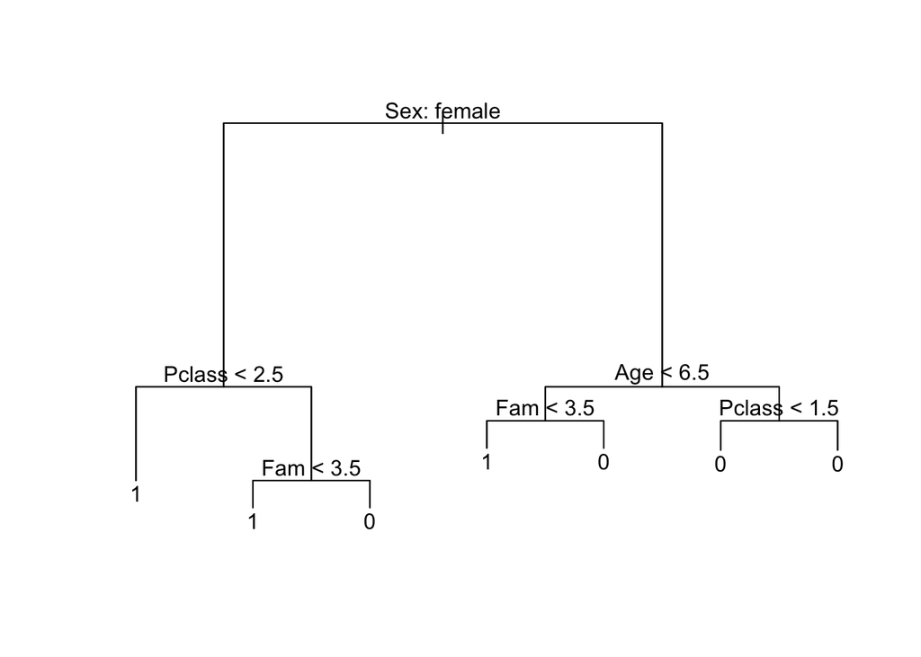

```r
#Plot the tree
plot(class_tree)
text(class_tree, pretty = 0)
```

##### By setting type as class we are telling the predict function that we want to classify the validation set that we pass as the new “unknown” data. The threshold for our classification is 0.5 such that any prediction that is over 0.5 will be classified as survived and anything equal to or below 0.5 will indicate death

```r
#Predict whether the person survived or not by using the algorithm
final_validation$predtree <- predict(class_tree, final_validation, type = "class")

#Assign 1 or 0 to the predictions that we made
final_validation$newtree[as.integer(final_validation$predtree) > 0.5] <- 1
final_validation$newtree[as.integer(final_validation$predtree) <= 0.5] <- 0
```

```r
#Create a confusion matrix
conf_tab_tree <- table(final_validation$predtree, final_validation$Survived)
conf_tab_tree
```

```
##
##       0   1
##   0 100  19
##   1  11  48
```

```r
#Calculate the misclassification error
misclassification_tree <- (conf_tab_tree[1,2] + conf_tab_tree[2,1])/(conf_tab_tree[1,1] + conf_tab_tree[1,2] + conf_tab_tree[2,1] + conf_tab_tree[2,2])

paste0("Prediction accuracy is: ", round(100*(1-misclassification_tree), 2), "%", sep="")
```

```
## [1] "Prediction accuracy is: 83.15%"
```

##### Check to see if pruning the tree will improve the prediction accuracy

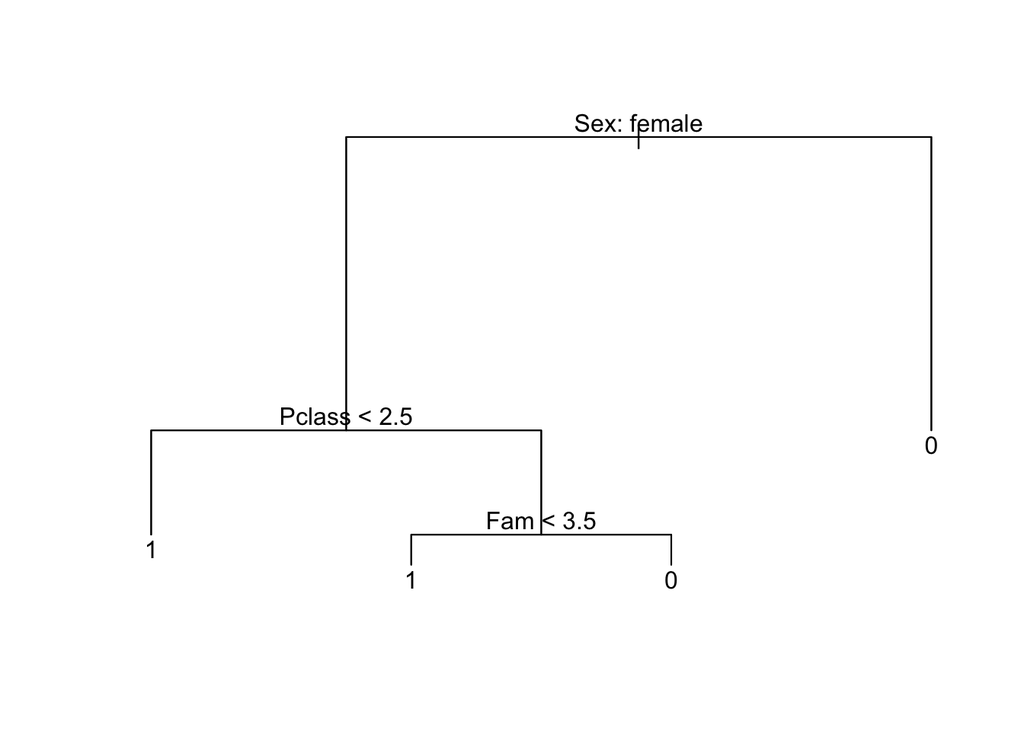

```r
#cv_trees <- cv.tree(class_tree, FUN = prune.misclass)
#Perform the pruning of the tree
prune_trees <- prune.misclass(class_tree, best = 4)

#Plot the pruned tree
plot(prune_trees)
text(prune_trees, pretty = 0)
```

```r
#Predict whether the person survived or not by using the algorithm
tree_pred <- predict(prune_trees, final_validation, type = "class")

#Create a confusion matrix
conf_tab_tr <- table(tree_pred, final_validation$Survived)

#Calculate the misclassification error
misclassification_tr <- (conf_tab_tr[1,2] + conf_tab_tr[2,1])/(conf_tab_tr[1,1] + conf_tab_tr[1,2] + conf_tab_tr[2,1] + conf_tab_tr[2,2])

paste0("Prediction accuracy is: ", round(100*(1-misclassification_tr), 2), "%", sep="")
```

```
## [1] "Prediction accuracy is: 81.46%"
```

# Random Forest

##### Use the random forest algorithm to create a model for prediction

```r
str(final_training)
```

```
## 'data.frame':    712 obs. of  15 variables:
##  $ PassengerId: int  269 647 460 764 746 354 625 363 228 264 ...
##  $ Survived   : int  1 0 0 1 0 0 0 0 0 0 ...
##  $ Pclass     : int  1 3 3 1 1 3 3 3 3 1 ...
##  $ Name       : chr  "Graham, Mrs. William Thompson (Edith Junkins)" "Cor, Mr. Liudevit" "O'Connor, Mr. Maurice" "Carter, Mrs. William Ernest (Lucile Polk)" ...
##  $ Sex        : Factor w/ 2 levels "female","male": 1 2 2 1 2 2 2 1 2 2 ...
##  $ Age        : num  58 19 32.4 36 70 ...
##  $ SibSp      : int  0 0 0 1 1 1 0 0 0 0 ...
##  $ Parch      : int  1 0 0 2 1 0 0 1 0 0 ...
##  $ Ticket     : chr  "PC 17582" "349231" "371060" "113760" ...
##  $ Fare       : num  153.46 7.9 7.75 120 71 ...
##  $ Cabin      : chr  "C125" "" "" "B96 B98" ...
##  $ Embarked   : Factor w/ 4 levels "","C","Q","S": 4 4 3 4 4 4 4 2 4 4 ...
##  $ LastName   : chr  "Graham" "Cor" "O'Connor" "Carter" ...
##  $ Title      : chr  "Mrs." "Mr." "Mr." "Mrs." ...
##  $ Fam        : int  1 0 0 3 2 1 0 1 0 0 ...
```

```r
final_training$Title <- as.factor(final_training$Title)
rf_titanic <- randomForest(as.factor(Survived) ~ Pclass +  Sex + Age + Fam + Title +
                             Pclass*Fam + Sex*Fam + Age*Title +Embarked, data = final_training, mtry = 3, importance = T, ntree = 3000)

final_validation$Title <- as.factor(final_validation$Title)
```

##### Once we create the model, use the predict function to classify the new “unknown” data in the validation set. This time our threshold is 0.4 such that any prediction over 0.4 gets classified as survived whereas anything equal to or lower than 0.4 gets classified as death

```r
final_validation$predicted_rf <- predict(rf_titanic, final_validation, type = "class")
final_validation$new_rf[as.integer(final_validation$predicted_rf) > 0.4] <- 1
final_validation$new_rf[as.integer(final_validation$predicted_rf) <= 0.4] <- 0
```

##### Create a confusion matrix and calculate the prediction accuracy

```r
conf_tab_rf <- table(final_validation$predicted_rf, final_validation$Survived)
conf_tab_rf
```

```
##
##       0   1
##   0 101  21
##   1  10  46
```

```r
misclassification_rf <- (conf_tab_rf[1,2] + conf_tab_rf[2,1])/(conf_tab_rf[1,1] + conf_tab_rf[1,2] + conf_tab_rf[2,1] + conf_tab_rf[2,2])
paste0("Prediction accuracy is: ", round(100*(1-misclassification_rf), 2), "%", sep="")
```

```
## [1] "Prediction accuracy is: 82.58%"
```

# Decision Tree Modified

##### Here we use another package to perform the decision tree algorithm. We create a better decision tree visualization to give more information to the user

[figure not shown]

```r
dt_mod <- rpart(Survived ~ Pclass + Sex + Age + Fam + Title + Embarked,
               data=final_training,
               method="class")

plot(dt_mod)
text(dt_mod)
```

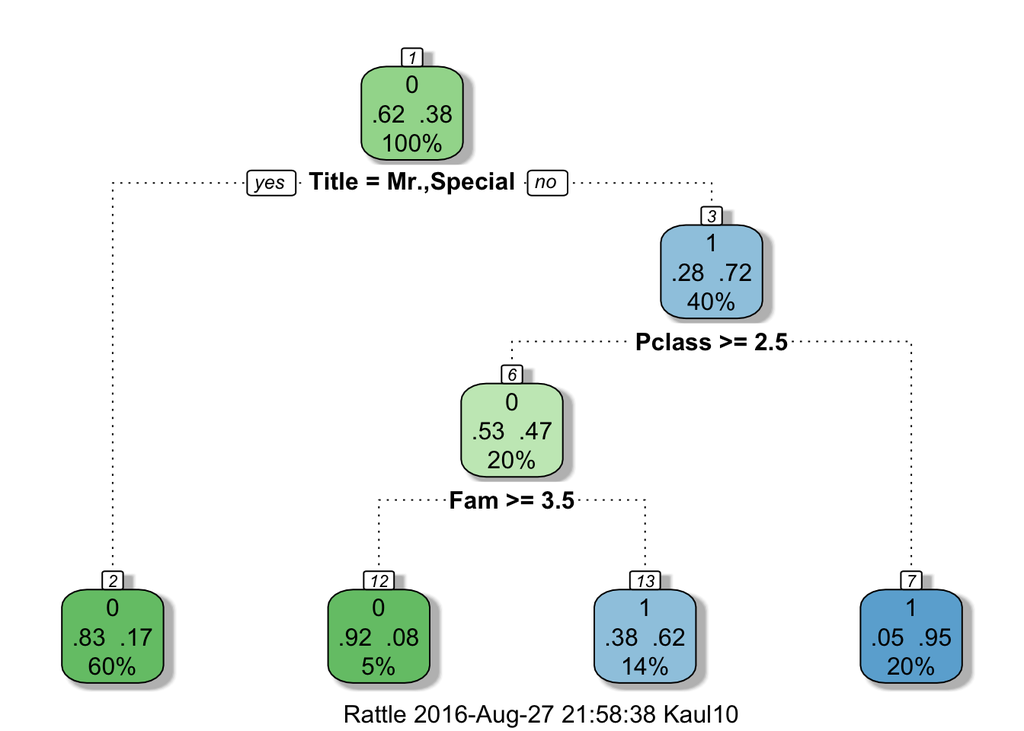

```r
fancyRpartPlot(dt_mod)
```

##### Once we create our model we can use the predict function to classify the new “unknown” data. Create a confusion matrix and then find the prediction accuracy of the model

```r
final_validation$mod_dt_pred <- predict(dt_mod, final_validation, type = "class")

conf_tab_dt_mod <- table(final_validation$mod_dt_pred, final_validation$Survived)
conf_tab_dt_mod
```

```
##
##       0   1
##   0 100  17
##   1  11  50
```

```r
misclassification_dt_mod <- (conf_tab_dt_mod[1,2] + conf_tab_dt_mod[2,1])/(conf_tab_dt_mod[1,1] + conf_tab_dt_mod[1,2] + conf_tab_dt_mod[2,1] + conf_tab_dt_mod[2,2])
paste0("Prediction accuracy is: ", round(100*(1-misclassification_dt_mod), 2), "%", sep="")
```

```
## [1] "Prediction accuracy is: 84.27%"
```

# CForest

##### Here we use an implementation of random forest and bagging ensemble algorithm which is also known as conditional forest

```r
#Add embarked here but make sure that the "" values are replaced to give only 3 factors
cf <- cforest(as.factor(Survived) ~ Pclass + Sex + Age + Fam + Fare + Title,
                 data = final_training,
                 controls=cforest_unbiased(ntree=2000, mtry=3))
```

##### Once the model has been created we predict the value for a validation set that contains “unknown” data. Finally, we check the prediction accuracy for this latest model to check whether it predicts the survival better than our other models

```r
final_validation$mod_cf_pred <- predict(cf, final_validation, OOB = T, type = "response")

conf_tab_cf_mod <- table(final_validation$mod_cf_pred, final_validation$Survived)
conf_tab_cf_mod
```

```
##
##       0   1
##   0 100  19
##   1  11  48
```

```r
misclassification_cf_mod <- (conf_tab_cf_mod[1,2] + conf_tab_cf_mod[2,1])/(conf_tab_cf_mod[1,1] + conf_tab_cf_mod[1,2] + conf_tab_cf_mod[2,1] + conf_tab_cf_mod[2,2])
paste0("Prediction accuracy is: ", round(100*(1-misclassification_cf_mod), 2), "%", sep="")
```

```
## [1] "Prediction accuracy is: 83.15%"
```